# Data Analysis: Users

## How to use this document

This R Markdown document includes the exercises for Part 5 of the workshop, [Working with Twitter Data in R](https://resulumit.com/teaching/twtr_workshop.html#1). It introduces each exercise with a subtitle, followed by some explanations and a code chunk. Type your code into these chunks to complete the exercises.

If these exercises are too easy for you, I recommend analysing your own dataset or conducting additional analyses on the same dataset in parallel. If they are on the other hand too hard, you may wish to follow on with the `users_answers.Rmd` instead, which include the code. In that case, try to adopt the code to your data as well.

If you have the `rmarkdown` package installed, you can see the results in two ways:

1. by clicking on the *Knit* button on the RStudio menu
   - this runs the codes in all chunks
   - the results will appear in a separate HTML document that will pop up
2. by clicking on the green arrow on the top-right corner of any chunk
   - this runs the code in that chunk only
   - the result will appear immediately under the relevant chunk

### Correlates of being on Twitter

Looking at the `mps` dataset, we can see that not all MPs have an account on Twitter. Specifically, 588 out of 650 MPs use Twitter. How can we explain that some of them are not on Twitter?

Use the variables from the `mps` dataset to explore.

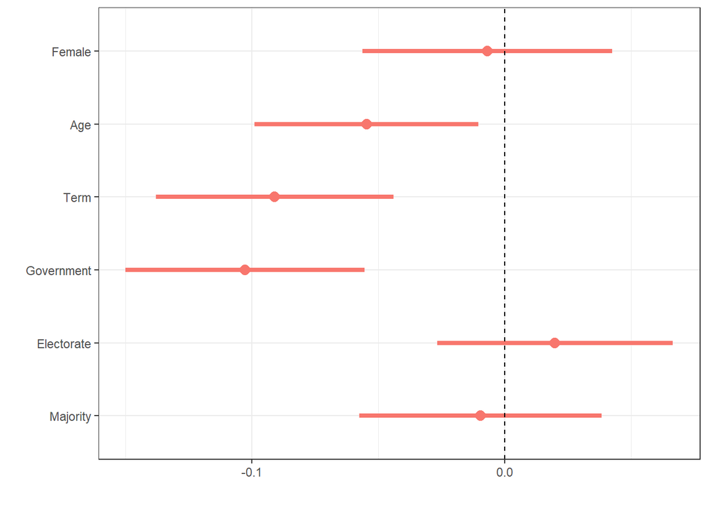

```
## $x
## [1] "Regression Coefficient"
##
## attr(,"class")
## [1] "labels"
```

### Who has the most followers?

Recall that the `tweets` dataset includes a variable called `followers_count`, measuring the number of followers that MPs have, at the time of data collection. Based on this variable, visualise the top 20 MPs with the highest number of followers.

Optionally, use the `name` and `party` variables from the `mps` dataset to improve the graph.

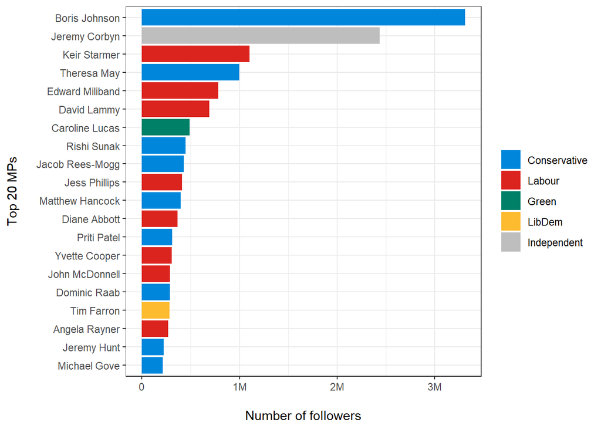

### Correlates of having more followers

How can we explain that some MPs have more followers than others? Looking at the MP-level correlates of followers might be informative. Use the variables from the `mps` dataset as independent variables, to run a regression model with the number of followers being the dependent variable.

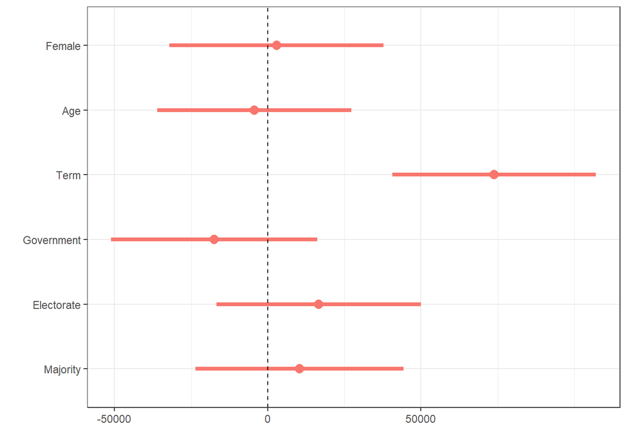

```
## $x
## [1] "Regression Coefficient"
##
## attr(,"class")
## [1] "labels"
```

### Who tweets the most often?

Optionally, use the `name` and `party` variables from the `mps` dataset to improve the graph.

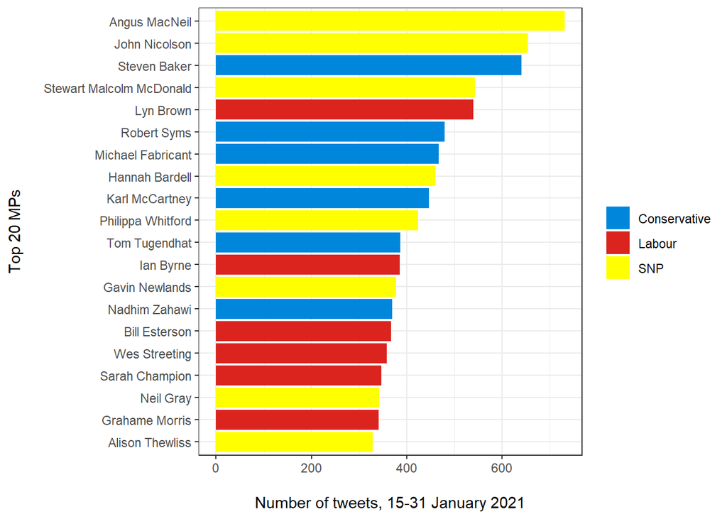

### Correlates of having more tweets

How can we explain that some MPs tweet more often than others? Looking at the MP-level correlates of the number of tweets might be informative. Use the variables from the `mps` dataset as independent variables, to run a regression model with the number of tweets posted being the dependent variable.

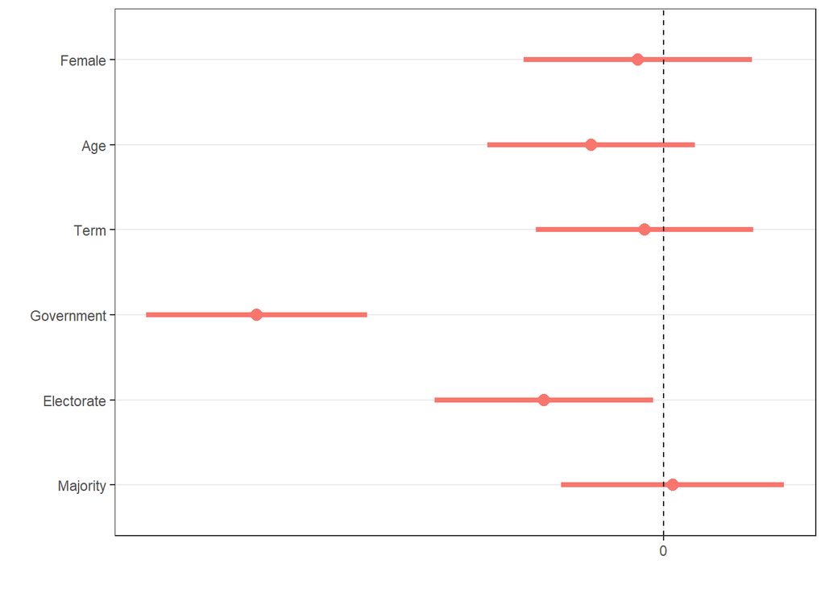

```
## $x
## [1] "Regression Coefficient"
##
## attr(,"class")
## [1] "labels"
```

### Who do they talk to?

Conventional wisdom suggests that MPs are more likely to interact with MPs from their own party. Does this hold on Twitter, in terms of who MPs reply to? What is the share of in- and out-party replies on Twitter?

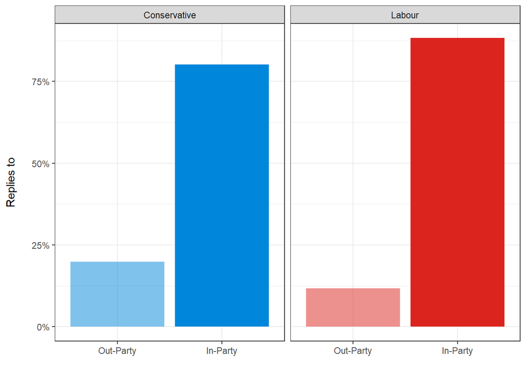

### Reply networks

We can think about “who replies to whom, how often” on Twitter as a network. In this sense, MPs would be the `nodes` while the replies would be the `edges`. We could also argue that this would be a `directed` network, from those who reply towards those who are replied to.

Visualise the directed network of replies, among the SNP MPs.

```
## Using `stress` as default layout
```

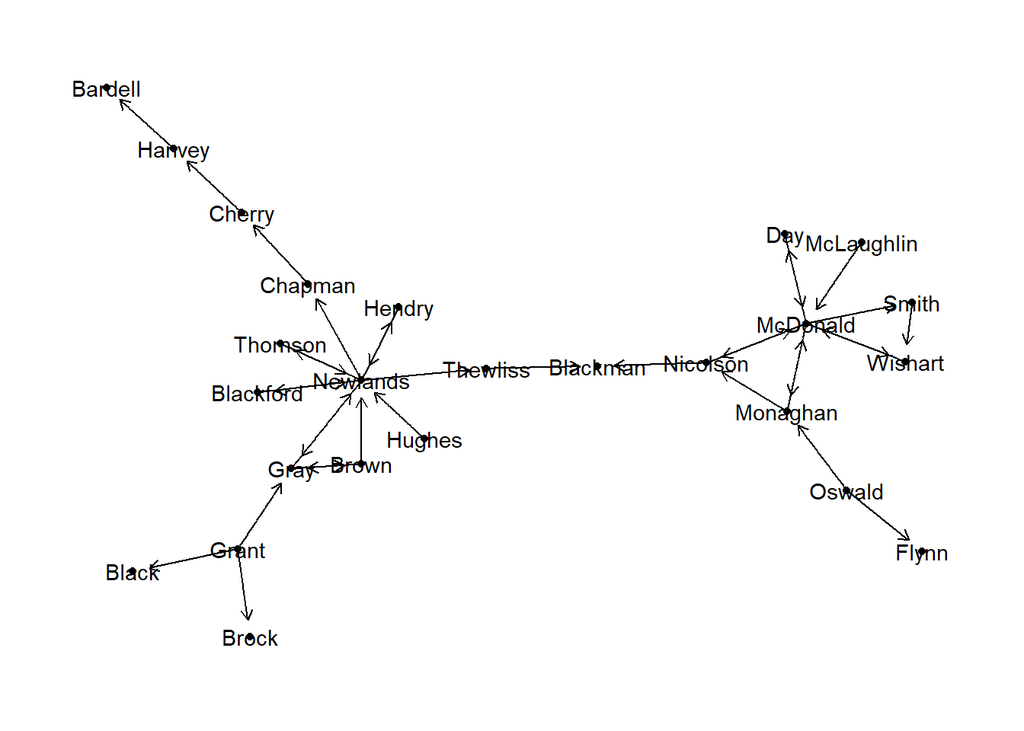

### Retweet networks

We can think about “who retweets whom, how often” on Twitter as a network as well . In this sense, MPs would be the `nodes` while the retweets would be the `edges`.

Visualise the network of retweets, among the MPs from four main parties: Conservative, Labour, SNP, and LibDem.

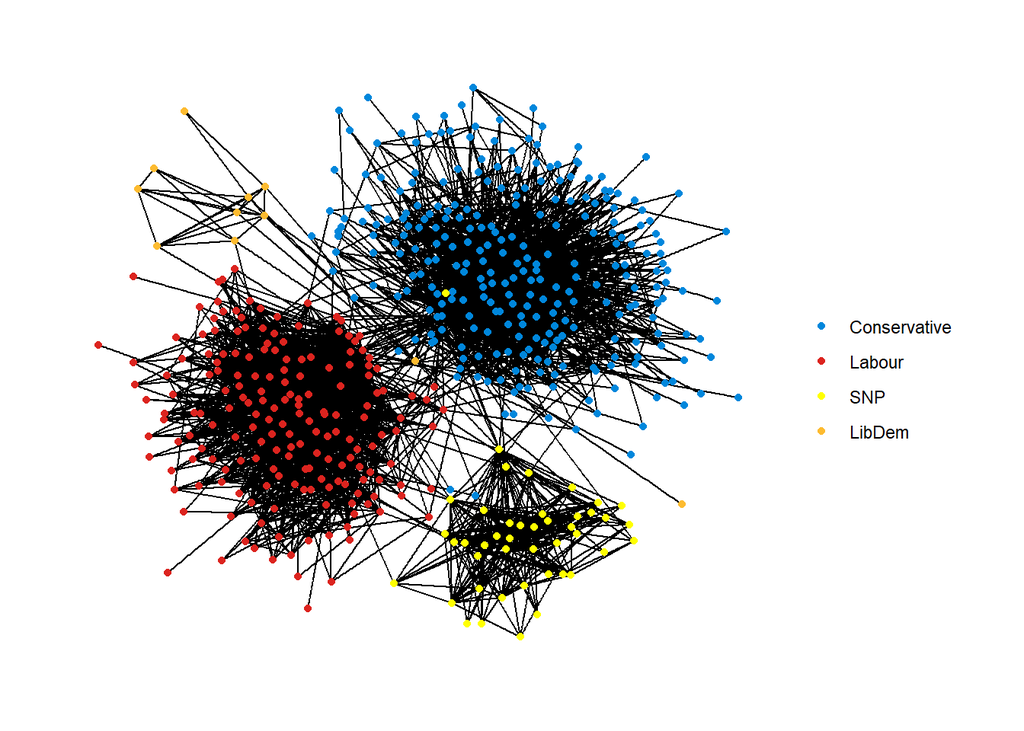

### Who are more central in the retweet networks?

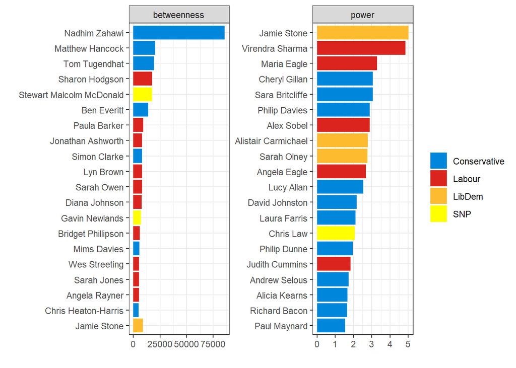

### Something else interesting about MPs

Conduct another user-based analysis of the `tweets` dataset — something that interests you. Work in groups of two, on the same datasets of one that you might have. Present your results to the class.

### Something interesting from your own data

Conduct another user-based analysis of the dataset that you have collected. Work on your own. Present your results to the class.